# 31 ICE: Extract register data

Author

Affiliation

Vladimir Buskin

Catholic University of Eichstätt-Ingolstadt

**Script**

You can find the full R script associated with this unit [here](https://osf.io/ny2g3).

## 31.1 Preparation

This supplementary unit illustrates how to extract register information from `kwic()` queries performed on data from the International Corpus of English (cf. Concordancing). We begin by loading the relevant libraries:

```r
library(tidyverse)
library(readxl)
```

Next we load some sample data to work with, which you can download [here](https://osf.io/y5scq). If you have data of your own, you may skip this step.

```r
# Load data
data_eat <- read_xlsx("eat_obj_aspect.xlsx")
```

The dataset follows the default `kwic()` structure with the document name and the immediate context before and after the keyword. The columns `object_realisation` (dependent variable) and `verb_aspect` (indepdent variable) are the result of manual annotation in Microsoft Excel.

```r
# First few lines
head(data_eat)
```

```
# A tibble: 6 × 9
  docname  from    to pre   keyword post  pattern object_realisation verb_aspect
  <chr>   <dbl> <dbl> <chr> <chr>   <chr> <chr>   <chr>              <chr>
1 ICE_GB…   458   458 had … eaten   anyw… "\\b(e… no                 perfective
2 ICE_GB…   478   478 : 1 … eating  will… "\\b(e… no                 progressive
3 ICE_GB…   785   785 > Ye… eat     befo… "\\b(e… no                 neutral
4 ICE_GB…  1198  1198 the … eat     them… "\\b(e… yes                neutral
5 ICE_GB…  4529  4529 > Ye… ate     in t… "\\b(e… no                 neutral
6 ICE_GB…   958   958 know… eat     it f… "\\b(e… yes                neutral
```

## 31.2 Fine-grained: Text categories

After querying the ICE corpora, information on the texts (and, therefore, the register) is stored in the `docname` column.

```r
head(data_eat[,"docname"])
```

```
# A tibble: 6 × 1
  docname
  <chr>
1 ICE_GB/S1A-006.txt
2 ICE_GB/S1A-006.txt
3 ICE_GB/S1A-006.txt
4 ICE_GB/S1A-009.txt
5 ICE_GB/S1A-009.txt
6 ICE_GB/S1A-010.txt
```

We want to split up this column into two separate ones. One should contain the text category labels (S1A, S1B, S2A etc.) and one the file numbers (001, 002, 003 etc.). The tidyverse function `seperate_wider_delim()` offers a method to handle that. Let’s call the new columns `text_category` and `file_number`, respectively.

If you apply the function to your own data, simply exchange the `data =` argument with your search results, and leave the rest as is.

```r
data_eat_reg <- separate_wider_delim(
                                # Original data frame
                                data = data_eat,
                                # Which column to split
                                cols = docname,
                                # Where to split it (at the hyphen)
                                delim = "-", # where to split exactly
                                # Names of the new columns
                                names = c("text_category", "file_number")
                                )
```

The data frame now have the desired format, as the first two columns indicate:

```r
head(data_eat_reg)
```

```
# A tibble: 6 × 10
  text_category file_number  from    to pre                keyword post  pattern
  <chr>         <chr>       <dbl> <dbl> <chr>              <chr>   <chr> <chr>
1 ICE_GB/S1A    006.txt       458   458 had lunch < ICE-G… eaten   anyw… "\\b(e…
2 ICE_GB/S1A    006.txt       478   478 : 1 : A > Well I … eating  will… "\\b(e…
3 ICE_GB/S1A    006.txt       785   785 > Yeah < ICE-GB:S… eat     befo… "\\b(e…
4 ICE_GB/S1A    009.txt      1198  1198 the summer < ICE-… eat     them… "\\b(e…
5 ICE_GB/S1A    009.txt      4529  4529 > Yeah < , > < IC… ate     in t… "\\b(e…
6 ICE_GB/S1A    010.txt       958   958 know I mean it wo… eat     it f… "\\b(e…
# ℹ 2 more variables: object_realisation <chr>, verb_aspect <chr>
```

## 31.3 More general: Spoken vs. written

If there is no need for the fine-grained register distinctions illustrated above, we might as well group them into macro-categories instead, such as **spoken** data and **written** data.

**Summary of text categories in the ICE corpora**

| Category | Subcategory | Type | Code Range |
| --- | --- | --- | --- |
| **SPOKEN (S)** | **DIALOGUE (S1)** | **PRIVATE (S1A)** |  |
|  |  | Direct Conversations | S1A-001 to S1A-090 |
|  |  | Telephone Calls | S1A-091 to S1A-100 |
|  | **PUBLIC (S1B)** |  |  |
|  |  | Class Lessons | S1B-001 to S1B-020 |
|  |  | Broadcast Discussions | S1B-021 to S1B-040 |
|  |  | Broadcast Interviews | S1B-041 to S1B-050 |
|  |  | Parliamentary Debates | S1B-051 to S1B-060 |
|  |  | Legal Cross-examinations | S1B-061 to S1B-070 |
|  |  | Business Transactions | S1B-071 to S1B-080 |
| **MONOLOGUE (S2)** | **UNSCRIPTED (S2A)** |  |  |
|  |  | Spontaneous Commentaries | S2A-001 to S2A-020 |
|  |  | Unscripted Speeches | S2A-021 to S2A-050 |
|  |  | Demonstrations | S2A-051 to S2A-060 |
|  |  | Legal Presentations | S2A-061 to S2A-070 |
|  | **SCRIPTED (S2B)** |  |  |
|  |  | Broadcast News | S2B-001 to S2B-020 |
|  |  | Broadcast Talks | S2B-021 to S2B-040 |
|  |  | Non-broadcast Talks | S2B-041 to S2B-050 |
| **WRITTEN (W)** | **NON-PRINTED (W1)** |  |  |
|  | **NON-PROFESSIONAL WRITING (W1A)** |  |  |
|  |  | Student Essays | W1A-001 to W1A-010 |
|  |  | Examination Scripts | W1A-011 to W1A-020 |
|  | **CORRESPONDENCE (W1B)** |  |  |
|  |  | Social Letters | W1B-001 to W1B-015 |
|  |  | Business Letters | W1B-016 to W1B-030 |
| **PRINTED (W2)** | **ACADEMIC WRITING (W2A)** |  |  |
|  |  | Humanities | W2A-001 to W2A-010 |
|  |  | Social Sciences | W2A-011 to W2A-020 |
|  |  | Natural Sciences | W2A-021 to W2A-030 |
|  |  | Technology | W2A-031 to W2A-040 |
|  | **NON-ACADEMIC WRITING (W2B)** |  |  |
|  |  | Humanities | W2B-001 to W2B-010 |
|  |  | Social Sciences | W2B-011 to W2B-020 |
|  |  | Natural Sciences | W2B-021 to W2B-030 |
|  |  | Technology | W2B-031 to W2B-040 |
|  | **REPORTAGE (W2C)** | Press News Reports | W2C-001 to W2C-020 |
|  | **INSTRUCTIONAL WRITING (W2D)** |  |  |
|  |  | Administrative Writing | W2D-001 to W2D-010 |
|  |  | Skills & Hobbies | W2D-011 to W2D-020 |
|  | **PERSUASIVE WRITING (W2E)** | Press Editorials | W2E-001 to W2E-010 |
|  | **CREATIVE WRITING (W2F)** | Novels & Stories | W2F-001 to W2F-020 |

What all spoken files have in common is that they begin with the upper-case letter `"S"`, and written files with `"W"`.

```r
# Classify text files as either "spoken" or "written"
data_eat_reg %>%
  mutate(medium = case_when(
    grepl("ICE_GB/S", text_category) ~ "spoken",
    grepl("ICE_GB/W", text_category) ~ "written"
  )) -> data_sw
```

**1**

Take the data frame `data_eat_reg` and pass it on to the next function via the pipe operator `%>%`. Make sure `library(tidyverse)` is loaded.

**2**

Create a new column with `mutate` and call it `medium`. The column values are assigned conditionally with `case_when()`:

**3**

If `text_category` contains the string `"ICE_GB/S"`, classify `medium` as `"spoken"`.

**4**

If `text_category` contains the string `"ICE_GB/W"`, classify `medium` as `"written"`.

**5**

Store the new data frame in the variable `data_sw`.

## 31.4 What next? A few sample analyses

It is now possible to investigate associations between register (i.e., `text_category` or `medium`) and other variables more comfortably.

- `object_realisation` and `text_category`

  ```r
  # Contingency table
  obj_reg_freq <- xtabs(~ object_realisation + text_category, data_eat_reg)

  # Percentage table
  object_reg_prop <- prop.table(obj_reg_freq, margin = 2) * 100

  print(object_reg_prop)
  ```

  ```
                    text_category
  object_realisation ICE_GB/S1A ICE_GB/S1B ICE_GB/S2A ICE_GB/S2B ICE_GB/W1B
                 no    61.22449   60.00000   50.00000   66.66667   90.00000
                 yes   38.77551   40.00000   50.00000   33.33333   10.00000
                    text_category
  object_realisation ICE_GB/W2B ICE_GB/W2C ICE_GB/W2D ICE_GB/W2E ICE_GB/W2F
                 no     0.00000  100.00000   50.00000  100.00000   50.00000
                 yes  100.00000    0.00000   50.00000    0.00000   50.00000
  ```

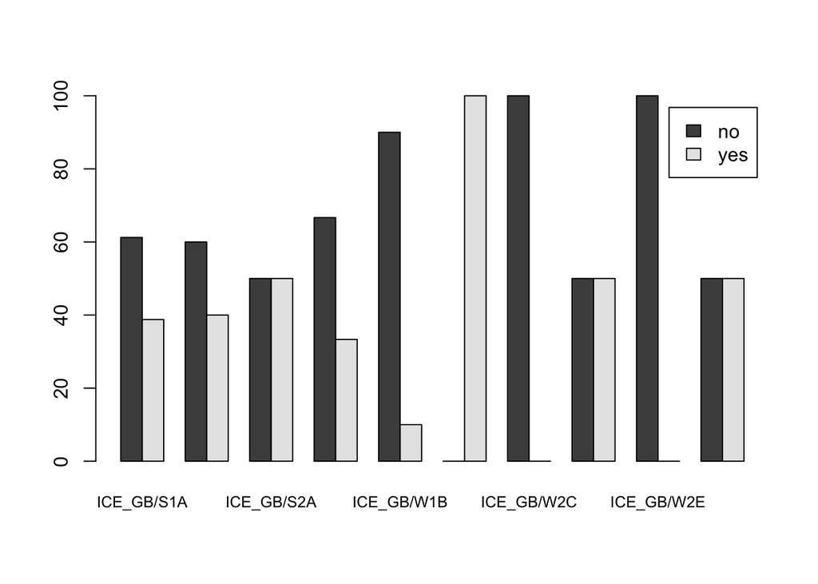

  ```r
  # Simple barplot
  barplot(object_reg_prop,
          beside = TRUE,
          legend = TRUE,
          cex.names = 0.8)
  ```

  ```r
  # Statistical analysis
  fisher.test(obj_reg_freq)
  ```

  ```
      Fisher's Exact Test for Count Data

  data:  obj_reg_freq
  p-value = 5.15e-05
  alternative hypothesis: two.sided
  ```

- `object_realisation` and `medium`

  ```r
  # Contingency table
  obj_sw_freq <- xtabs(~ object_realisation + medium, data_sw)

  # Percentage table
  obj_sw_prop <- prop.table(obj_sw_freq, margin = 2) * 100

  print(obj_sw_prop)
  ```

  ```
                    medium
  object_realisation   spoken  written
                 no  60.29412 47.05882
                 yes 39.70588 52.94118
  ```

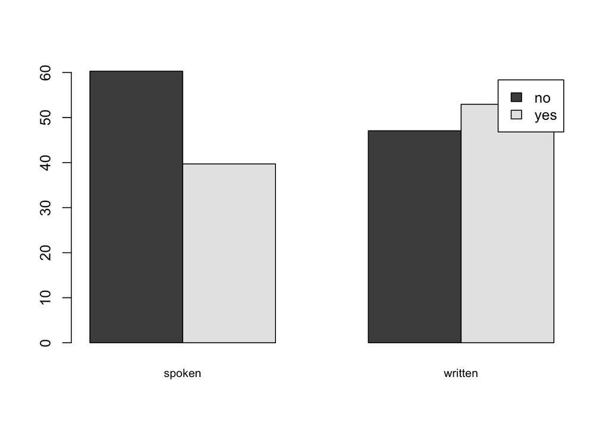

  ```r
  # Simple barplot
  barplot(obj_sw_prop,
          beside = TRUE,
          legend = TRUE,
          cex.names = 0.8)
  ```

  ```r
  # Statistical analysis
  chisq.test(obj_sw_freq)
  ```

  ```
      Pearson's Chi-squared test with Yates' continuity correction

  data:  obj_sw_freq
  X-squared = 1.1184, df = 1, p-value = 0.2903
  ```